# MATH3823 - Solution to Chapter 3 Exercises (Draft: 23/05/2023)

#### Using R Markdown files

If you are reading this online, on the module website, then this is output from an [R Markdown](http://rmarkdown.rstudio.com) Notebook. At the top-righthand corner of the page under $\texttt{Code}$, select $\texttt{Download Rmd}$ to download the original R Markdown notebook – this is recommended so that you can edit and re-run code within the notebook. When you run code within the notebook, the results appear beneath the code. If you do download the notebook, then try executing a chunk by clicking the *Run* button within the chunk or by placing your cursor inside it and pressing *Ctrl+Shift+Enter*.

#### Exercise 3.1

The estimate of $p$ is simply $\hat p = \bar y /m$, were $m=62$, that is $\hat p = 0.5866935$. Hence, here our model is $Y\sim \mbox{Bin}(62, 0.59)$ with fitted probabilities shown in blue below.

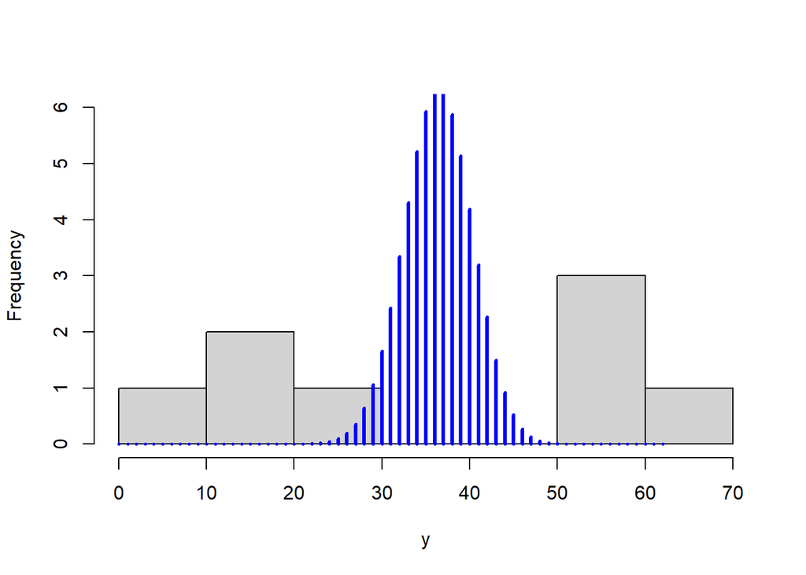

```r
y = c(6,13,18,28,52,53,61,60)
m = 62

hist(y, main="", ylim=c(0,6))

p.hat = mean(y)/m
fitted = m*dbinom(0:m, m, p.hat)
lines(0:m, fitted, type='h', lwd=3, col="blue")
```

Recall the original situation, with mortality against dose:

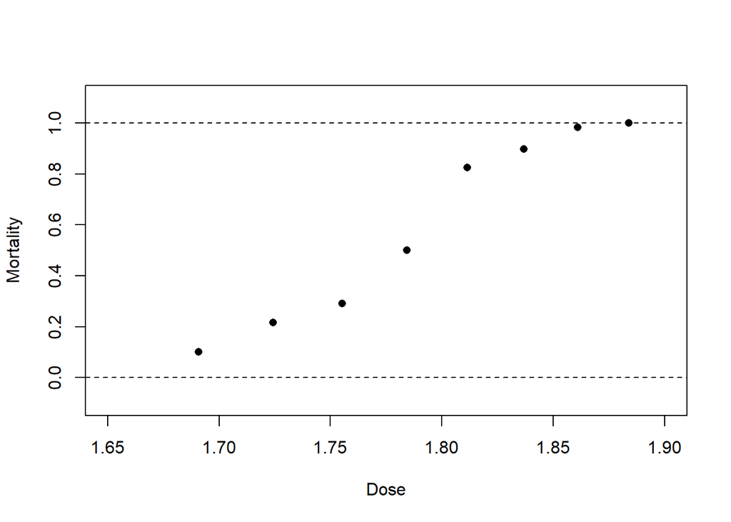

```r
beetle = read.table("https://rgaykroyd.github.io/MATH3823/Datasets/beetle.txt", header=T)

dose = beetle$dose
mortality = beetle$died/beetle$total

plot(dose, mortality, pch=16,
     xlim=c(1.65, 1.90), xlab ="Dose",
     ylim=c(-0.1, 1.1),  ylab="Mortality")
abline(h=c(0,1), lty=2)
```

We see that although the *average* mortality might be around $0.5$, it is very clear that the actually mortality is strongly dependent on dose. Here, the model misfit is caused by an imortant variable not being recorded.

#### Exercise 3.2

[See Solution for Questions 1 and 3 from *Exercises from Last Year*.]

#### Exercise 3.3

[See Solution for Question 3 from *Exercises from Last Year*.]

#### Exercise 3.4

To express this in exponential form we rearrange the probability mass function:
$$\begin{align*}
f(y)
&= \exp\{(y-1)\log (1-p) + \log p \} \\
&= \exp\{y \log (1-p) +\log \left\{ p/(1-p)\right\}
\end{align*}$$
Hence, we have that $\theta = \log(1-p)$ and hence $p=1-e^\theta$ and $1-p=e^\theta$. Further, $b(\theta)= \log \left\{ p/(1-p)\right\} = \log \left\{ e^{-\theta}-1\right\}$, $c(y, \theta)=0$ and $\phi=1$.

#### Exercise 3.5

For a discrete random variable, starting with the property that all probability mass functions sum to 1, we have
$$1 = \sum_{y\in \Omega_Y} \exp \left\{ \frac{y \theta - b(\theta)}{\phi}
+ c(y,\phi)\right\}$$
and then differentiating both sides with respect to $\theta$ gives
$$0 = \sum \left[\frac{ y - b'(\theta)}{\phi} \right]\exp \left\{
\frac{y \theta - b(\theta)}{\phi} + c(y,\phi)\right\}.$$
Next, using the definition of the exponential family to simplify the equation gives
$$0 = \sum \left[\frac{ y - b'(\theta)}{\phi} \right] f(y; \theta)\$$
and expanding the brackets leads to
$$0 = \frac{1}{\phi} \left(\sum y f(y; \theta) - b'(\theta) \sum
f(y;\theta) \right).$$
The first sum is simply the expectation of $Y$ and the second is the integral of the probability mass function of $Y$, and hence
$$0 = \frac{1}{\phi} \left(\mbox{E}[Y] - b'(\theta)\right)$$
which implies that
$$\mbox{E}[Y] = b'(\theta),$$
which proves the first part of the proposition.

Differentiating a second time, by parts and then using the definition of the exponential family to simplify again, yields
$$0 = \sum \left\{ -\frac{b''(\theta)}{\phi} + \left[\frac{ y -
b'(\theta)}{\phi} \right]^2 \right\} f(y; \theta)$$
and using the just prooved result about expectation gives,
$$0 = -\frac{b''(\theta)}{\phi} +\sum \left[\frac{ y -
\mbox{E}[Y]}{\phi} \right]^2 f(y; \theta)$$
and
$$0 = -\frac{b''(\theta)}{\phi} + \frac{\mbox{Var}[Y]}{\phi^2}$$
which implies that
$$\mbox{Var}[Y] = \phi \ b''(\theta).$$
which proves the second part of the proposition for discrete random variables.

For the Poisson, since $b(\theta)=e^\theta$ then $b'(\theta)=e^\theta$ and $b''(\theta)=e^\theta$. With $\theta=\log \lambda$ we get the usual, $\mbox{E}[Y]=\lambda$ and $\mbox{Var}[Y]=\lambda$.

For the binomial, $Y\sim \mbox{Bin}(n,p)$, $b(\theta)=n\log(1+e^\theta)$ and hence
$$b'(\theta) = n \frac{e^\theta}{(1+e^\theta)}$$
and
$$b''(\theta)= n\left( \frac{e^\theta}{(1+e^\theta)} -
\frac{(e^\theta)^2}{(1+e^\theta)^2}\right)= n\left(
\frac{e^\theta}{(1+e^\theta)^2}\right).$$

From $\theta = \mbox{logit}(p)$ we get $e^\theta = p/(1-p)$ and $1+e^\theta = 1/(1-p)$. These give,
$$\mbox{E}[Y]= n \frac{p/(1-p)}{1/(1-p)}=np$$
and
$$\mbox{Var}[Y]=n \frac{p/(1-p)}{1/(1-p)^2}= np(1-p)$$
– as expected.

#### Exercise 3.6

[See Solution for Question 3 from *Exercises from Last Year*.]

#### Exercise 3.7

[See Solution for Question 4 from *Exercises from Last Year*.]